# Risk Factor Analysis

## Outcome Variable

**Outcome Variable:** wasted

## Predictor Variables

**Intervention Variable:** earlybf

**Adjustment Set:**

- arm
- sex
- W_mage
- meducyrs
- feducyrs
- hhwealth_quart
- hfoodsec
- W_mhtcm
- W_mwtkg
- W_mbmi
- vagbrth
- W_gagebrth
- W_birthwt
- W_birthlen
- W_nrooms
- W_nchldlt5
- brthmon
- W_parity
- impfloor
- impsan
- safeh20
- delta_W_mage
- delta_meducyrs
- delta_feducyrs
- delta_hhwealth_quart
- delta_hfoodsec
- delta_W_mhtcm
- delta_W_mwtkg
- delta_W_mbmi
- delta_vagbrth
- delta_W_gagebrth
- delta_W_birthwt
- delta_W_birthlen
- delta_W_nrooms
- delta_W_nchldlt5
- delta_brthmon
- delta_W_parity
- delta_impfloor
- delta_impsan
- delta_safeh20

## Stratifying Variables

The analysis was stratified on these variable(s):

- agecat
- studyid
- country

## Data Summary

| agecat | studyid | country | earlybf | wasted | n_cell | n |
| --- | --- | --- | --- | --- | --- | --- |
| Birth | ki0047075b-MAL-ED | BANGLADESH | 1 | 0 | 120 | 214 |
| Birth | ki0047075b-MAL-ED | BANGLADESH | 1 | 1 | 20 | 214 |
| Birth | ki0047075b-MAL-ED | BANGLADESH | 0 | 0 | 58 | 214 |
| Birth | ki0047075b-MAL-ED | BANGLADESH | 0 | 1 | 16 | 214 |
| Birth | ki0047075b-MAL-ED | BRAZIL | 1 | 0 | 25 | 62 |
| Birth | ki0047075b-MAL-ED | BRAZIL | 1 | 1 | 1 | 62 |
| Birth | ki0047075b-MAL-ED | BRAZIL | 0 | 0 | 35 | 62 |
| Birth | ki0047075b-MAL-ED | BRAZIL | 0 | 1 | 1 | 62 |
| Birth | ki0047075b-MAL-ED | INDIA | 1 | 0 | 27 | 44 |
| Birth | ki0047075b-MAL-ED | INDIA | 1 | 1 | 4 | 44 |
| Birth | ki0047075b-MAL-ED | INDIA | 0 | 0 | 12 | 44 |
| Birth | ki0047075b-MAL-ED | INDIA | 0 | 1 | 1 | 44 |
| Birth | ki0047075b-MAL-ED | NEPAL | 1 | 0 | 13 | 26 |
| Birth | ki0047075b-MAL-ED | NEPAL | 1 | 1 | 1 | 26 |
| Birth | ki0047075b-MAL-ED | NEPAL | 0 | 0 | 11 | 26 |
| Birth | ki0047075b-MAL-ED | NEPAL | 0 | 1 | 1 | 26 |
| Birth | ki0047075b-MAL-ED | PERU | 1 | 0 | 169 | 228 |
| Birth | ki0047075b-MAL-ED | PERU | 1 | 1 | 3 | 228 |
| Birth | ki0047075b-MAL-ED | PERU | 0 | 0 | 54 | 228 |
| Birth | ki0047075b-MAL-ED | PERU | 0 | 1 | 2 | 228 |
| Birth | ki0047075b-MAL-ED | SOUTH AFRICA | 1 | 0 | 64 | 110 |
| Birth | ki0047075b-MAL-ED | SOUTH AFRICA | 1 | 1 | 5 | 110 |
| Birth | ki0047075b-MAL-ED | SOUTH AFRICA | 0 | 0 | 36 | 110 |
| Birth | ki0047075b-MAL-ED | SOUTH AFRICA | 0 | 1 | 5 | 110 |
| Birth | ki0047075b-MAL-ED | TANZANIA, UNITED REPUBLIC OF | 1 | 0 | 102 | 115 |
| Birth | ki0047075b-MAL-ED | TANZANIA, UNITED REPUBLIC OF | 1 | 1 | 1 | 115 |
| Birth | ki0047075b-MAL-ED | TANZANIA, UNITED REPUBLIC OF | 0 | 0 | 12 | 115 |
| Birth | ki0047075b-MAL-ED | TANZANIA, UNITED REPUBLIC OF | 0 | 1 | 0 | 115 |
| Birth | ki1000109-EE | PAKISTAN | 1 | 0 | 34 | 170 |
| Birth | ki1000109-EE | PAKISTAN | 1 | 1 | 2 | 170 |

[output cut: 134 more lines]

The following strata were considered:

- agecat: 24 months, studyid: ki0047075b-MAL-ED, country: BANGLADESH
- agecat: 24 months, studyid: ki0047075b-MAL-ED, country: BRAZIL
- agecat: 24 months, studyid: ki0047075b-MAL-ED, country: INDIA
- agecat: 24 months, studyid: ki0047075b-MAL-ED, country: NEPAL
- agecat: 24 months, studyid: ki0047075b-MAL-ED, country: PERU
- agecat: 24 months, studyid: ki0047075b-MAL-ED, country: SOUTH AFRICA
- agecat: 24 months, studyid: ki0047075b-MAL-ED, country: TANZANIA, UNITED REPUBLIC OF
- agecat: 24 months, studyid: ki1000109-EE, country: PAKISTAN
- agecat: 24 months, studyid: ki1017093c-NIH-Crypto, country: BANGLADESH
- agecat: 24 months, studyid: ki1113344-GMS-Nepal, country: NEPAL
- agecat: 24 months, studyid: ki1126311-ZVITAMBO, country: ZIMBABWE
- agecat: 24 months, studyid: kiGH5241-JiVitA-3, country: BANGLADESH
- agecat: 24 months, studyid: kiGH5241-JiVitA-4, country: BANGLADESH
- agecat: 6 months, studyid: ki0047075b-MAL-ED, country: BANGLADESH
- agecat: 6 months, studyid: ki0047075b-MAL-ED, country: BRAZIL
- agecat: 6 months, studyid: ki0047075b-MAL-ED, country: INDIA
- agecat: 6 months, studyid: ki0047075b-MAL-ED, country: NEPAL
- agecat: 6 months, studyid: ki0047075b-MAL-ED, country: PERU
- agecat: 6 months, studyid: ki0047075b-MAL-ED, country: SOUTH AFRICA
- agecat: 6 months, studyid: ki0047075b-MAL-ED, country: TANZANIA, UNITED REPUBLIC OF
- agecat: 6 months, studyid: ki1000109-EE, country: PAKISTAN
- agecat: 6 months, studyid: ki1000304b-SAS-CompFeed, country: INDIA
- agecat: 6 months, studyid: ki1017093c-NIH-Crypto, country: BANGLADESH
- agecat: 6 months, studyid: ki1113344-GMS-Nepal, country: NEPAL
- agecat: 6 months, studyid: ki1126311-ZVITAMBO, country: ZIMBABWE
- agecat: 6 months, studyid: kiGH5241-JiVitA-3, country: BANGLADESH
- agecat: 6 months, studyid: kiGH5241-JiVitA-4, country: BANGLADESH
- agecat: Birth, studyid: ki0047075b-MAL-ED, country: BANGLADESH
- agecat: Birth, studyid: ki0047075b-MAL-ED, country: BRAZIL
- agecat: Birth, studyid: ki0047075b-MAL-ED, country: INDIA
- agecat: Birth, studyid: ki0047075b-MAL-ED, country: NEPAL
- agecat: Birth, studyid: ki0047075b-MAL-ED, country: PERU
- agecat: Birth, studyid: ki0047075b-MAL-ED, country: SOUTH AFRICA
- agecat: Birth, studyid: ki0047075b-MAL-ED, country: TANZANIA, UNITED REPUBLIC OF
- agecat: Birth, studyid: ki1000109-EE, country: PAKISTAN
- agecat: Birth, studyid: ki1000304b-SAS-CompFeed, country: INDIA
- agecat: Birth, studyid: ki1017093c-NIH-Crypto, country: BANGLADESH
- agecat: Birth, studyid: ki1113344-GMS-Nepal, country: NEPAL
- agecat: Birth, studyid: ki1126311-ZVITAMBO, country: ZIMBABWE
- agecat: Birth, studyid: kiGH5241-JiVitA-3, country: BANGLADESH
- agecat: Birth, studyid: kiGH5241-JiVitA-4, country: BANGLADESH

### Dropped Strata

Some strata were dropped due to rare outcomes:

- agecat: Birth, studyid: ki0047075b-MAL-ED, country: BRAZIL
- agecat: Birth, studyid: ki0047075b-MAL-ED, country: INDIA
- agecat: Birth, studyid: ki0047075b-MAL-ED, country: NEPAL
- agecat: Birth, studyid: ki0047075b-MAL-ED, country: PERU
- agecat: Birth, studyid: ki0047075b-MAL-ED, country: TANZANIA, UNITED REPUBLIC OF
- agecat: Birth, studyid: ki1000109-EE, country: PAKISTAN
- agecat: 6 months, studyid: ki0047075b-MAL-ED, country: BANGLADESH
- agecat: 6 months, studyid: ki0047075b-MAL-ED, country: BRAZIL
- agecat: 6 months, studyid: ki0047075b-MAL-ED, country: NEPAL
- agecat: 6 months, studyid: ki0047075b-MAL-ED, country: PERU
- agecat: 6 months, studyid: ki0047075b-MAL-ED, country: SOUTH AFRICA
- agecat: 6 months, studyid: ki0047075b-MAL-ED, country: TANZANIA, UNITED REPUBLIC OF
- agecat: 6 months, studyid: ki1017093c-NIH-Crypto, country: BANGLADESH
- agecat: 24 months, studyid: ki0047075b-MAL-ED, country: BRAZIL
- agecat: 24 months, studyid: ki0047075b-MAL-ED, country: NEPAL
- agecat: 24 months, studyid: ki0047075b-MAL-ED, country: PERU
- agecat: 24 months, studyid: ki0047075b-MAL-ED, country: SOUTH AFRICA
- agecat: 24 months, studyid: ki0047075b-MAL-ED, country: TANZANIA, UNITED REPUBLIC OF
- agecat: 24 months, studyid: ki1000109-EE, country: PAKISTAN
- agecat: 24 months, studyid: ki1017093c-NIH-Crypto, country: BANGLADESH
- agecat: 24 months, studyid: kiGH5241-JiVitA-3, country: BANGLADESH

## Methods Detail

We’re interested in the causal parameters $E[Y_a]$ for all values of $a \in \mathcal{A}$. These parameters represent the mean outcome if, possibly contrary to fact, we intervened to set all units to have $A=a$. Under the randomization and positivity assumptions, these are identified by the statistical parameters $\psi_a=E_W[E_{Y|A,W}(Y|A=a,W)]$. In addition, we’re interested in the mean of $Y$, $E[Y]$ under no intervention (the observed mean). We will estimate these parameters by using SuperLearner to fit the relevant likelihood factors – $E_{Y|A,W}(Y|A=a,W)$ and $p(A=a|W)$, and then updating our likelihood fit using a joint TMLE.

For unadjusted analyses ($W=\{\}$), initial likelihoods were estimated using Lrnr_glm to estimate the simple $E(Y|A)$ and Lrnr_mean to estimate $p(A)$. For adjusted analyses, a small library containing Lrnr_glmnet, Lrnr_xgboost, and Lrnr_mean was used.

Having estimated these parameters, we will then use the delta method to estimate relative risks and attributable risks relative to a prespecified baseline level of $A$.

# Results Detail

## Results Plots

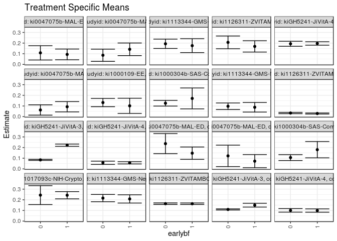

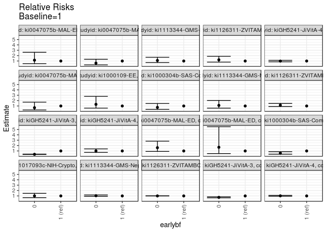

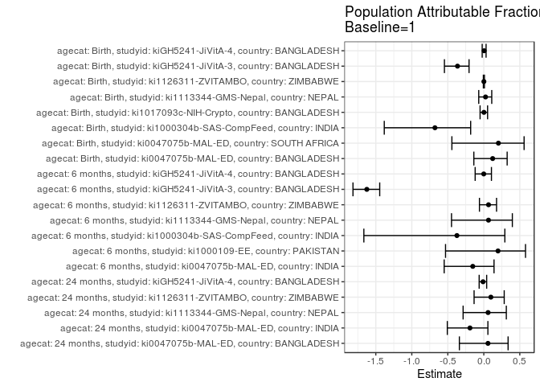

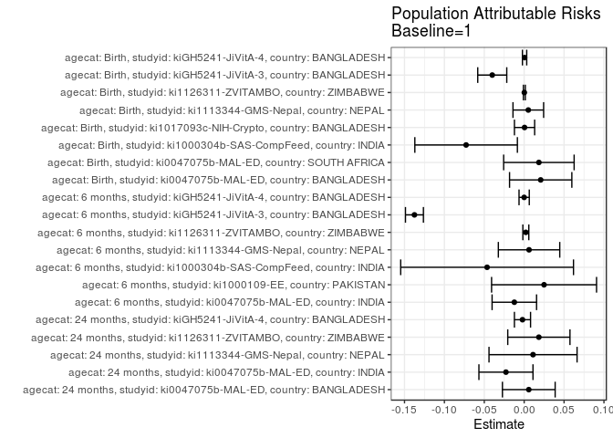

## Results Table

### Parameter: TSM

| agecat | studyid | country | intervention_level | baseline_level | estimate | ci_lower | ci_upper |
| --- | --- | --- | --- | --- | --- | --- | --- |
| Birth | ki0047075b-MAL-ED | BANGLADESH | 1 | NA | 0.1475231 | 0.0893369 | 0.2057094 |
| Birth | ki0047075b-MAL-ED | BANGLADESH | 0 | NA | 0.2367646 | 0.1426886 | 0.3308406 |
| Birth | ki0047075b-MAL-ED | SOUTH AFRICA | 1 | NA | 0.0724638 | 0.0110123 | 0.1339153 |
| Birth | ki0047075b-MAL-ED | SOUTH AFRICA | 0 | NA | 0.1219512 | 0.0213295 | 0.2225729 |
| Birth | ki1000304b-SAS-CompFeed | INDIA | 1 | NA | 0.1800632 | 0.1035793 | 0.2565471 |
| Birth | ki1000304b-SAS-CompFeed | INDIA | 0 | NA | 0.1058739 | 0.0785273 | 0.1332206 |
| Birth | ki1017093c-NIH-Crypto | BANGLADESH | 1 | NA | 0.2428230 | 0.2088738 | 0.2767722 |
| Birth | ki1017093c-NIH-Crypto | BANGLADESH | 0 | NA | 0.2438189 | 0.1552685 | 0.3323693 |
| Birth | ki1113344-GMS-Nepal | NEPAL | 1 | NA | 0.2081382 | 0.1694337 | 0.2468426 |
| Birth | ki1113344-GMS-Nepal | NEPAL | 0 | NA | 0.2160006 | 0.1819026 | 0.2500987 |
| Birth | ki1126311-ZVITAMBO | ZIMBABWE | 1 | NA | 0.1630816 | 0.1562432 | 0.1699200 |
| Birth | ki1126311-ZVITAMBO | ZIMBABWE | 0 | NA | 0.1635747 | 0.1566862 | 0.1704633 |
| Birth | kiGH5241-JiVitA-3 | BANGLADESH | 1 | NA | 0.1495931 | 0.1317755 | 0.1674108 |
| Birth | kiGH5241-JiVitA-3 | BANGLADESH | 0 | NA | 0.1093160 | 0.1040611 | 0.1145710 |
| Birth | kiGH5241-JiVitA-4 | BANGLADESH | 1 | NA | 0.0992562 | 0.0837755 | 0.1147370 |
| Birth | kiGH5241-JiVitA-4 | BANGLADESH | 0 | NA | 0.1008940 | 0.0842060 | 0.1175820 |
| 6 months | ki0047075b-MAL-ED | INDIA | 1 | NA | 0.0928571 | 0.0446788 | 0.1410355 |
| 6 months | ki0047075b-MAL-ED | INDIA | 0 | NA | 0.0625000 | 0.0139756 | 0.1110244 |
| 6 months | ki1000109-EE | PAKISTAN | 1 | NA | 0.1014493 | 0.0301120 | 0.1727866 |
| 6 months | ki1000109-EE | PAKISTAN | 0 | NA | 0.1322034 | 0.0934986 | 0.1709082 |
| 6 months | ki1000304b-SAS-CompFeed | INDIA | 1 | NA | 0.1709216 | 0.0729186 | 0.2689247 |
| 6 months | ki1000304b-SAS-CompFeed | INDIA | 0 | NA | 0.1258323 | 0.0989194 | 0.1527451 |
| 6 months | ki1113344-GMS-Nepal | NEPAL | 1 | NA | 0.0878252 | 0.0427756 | 0.1328748 |
| 6 months | ki1113344-GMS-Nepal | NEPAL | 0 | NA | 0.0974651 | 0.0667844 | 0.1281459 |
| 6 months | ki1126311-ZVITAMBO | ZIMBABWE | 1 | NA | 0.0294381 | 0.0241991 | 0.0346771 |
| 6 months | ki1126311-ZVITAMBO | ZIMBABWE | 0 | NA | 0.0338807 | 0.0278178 | 0.0399436 |
| 6 months | kiGH5241-JiVitA-3 | BANGLADESH | 1 | NA | 0.2222222 | 0.2115818 | 0.2328627 |
| 6 months | kiGH5241-JiVitA-3 | BANGLADESH | 0 | NA | 0.0843683 | 0.0794631 | 0.0892735 |
| 6 months | kiGH5241-JiVitA-4 | BANGLADESH | 1 | NA | 0.0569341 | 0.0464762 | 0.0673919 |
| 6 months | kiGH5241-JiVitA-4 | BANGLADESH | 0 | NA | 0.0572616 | 0.0420169 | 0.0725063 |
| 24 months | ki0047075b-MAL-ED | BANGLADESH | 1 | NA | 0.0937500 | 0.0431344 | 0.1443656 |
| 24 months | ki0047075b-MAL-ED | BANGLADESH | 0 | NA | 0.1084337 | 0.0413836 | 0.1754839 |
| 24 months | ki0047075b-MAL-ED | INDIA | 1 | NA | 0.1417910 | 0.0825974 | 0.2009847 |
| 24 months | ki0047075b-MAL-ED | INDIA | 0 | NA | 0.0860215 | 0.0289083 | 0.1431348 |
| 24 months | ki1113344-GMS-Nepal | NEPAL | 1 | NA | 0.1758332 | 0.1106835 | 0.2409829 |
| 24 months | ki1113344-GMS-Nepal | NEPAL | 0 | NA | 0.1934509 | 0.1497193 | 0.2371824 |
| 24 months | ki1126311-ZVITAMBO | ZIMBABWE | 1 | NA | 0.1689276 | 0.1159703 | 0.2218849 |
| 24 months | ki1126311-ZVITAMBO | ZIMBABWE | 0 | NA | 0.2067434 | 0.1468020 | 0.2666847 |
| 24 months | kiGH5241-JiVitA-4 | BANGLADESH | 1 | NA | 0.1964232 | 0.1804228 | 0.2124236 |
| 24 months | kiGH5241-JiVitA-4 | BANGLADESH | 0 | NA | 0.1936469 | 0.1700052 | 0.2172885 |

### Parameter: E(Y)

| agecat | studyid | country | intervention_level | baseline_level | estimate | ci_lower | ci_upper |
| --- | --- | --- | --- | --- | --- | --- | --- |
| Birth | ki0047075b-MAL-ED | BANGLADESH | NA | NA | 0.1682243 | 0.1179894 | 0.2184592 |
| Birth | ki0047075b-MAL-ED | SOUTH AFRICA | NA | NA | 0.0909091 | 0.0369404 | 0.1448778 |
| Birth | ki1000304b-SAS-CompFeed | INDIA | NA | NA | 0.1072761 | 0.0774575 | 0.1370947 |
| Birth | ki1017093c-NIH-Crypto | BANGLADESH | NA | NA | 0.2432815 | 0.2116319 | 0.2749310 |
| Birth | ki1113344-GMS-Nepal | NEPAL | NA | NA | 0.2133106 | 0.1801152 | 0.2465060 |
| Birth | ki1126311-ZVITAMBO | ZIMBABWE | NA | NA | 0.1632795 | 0.1565278 | 0.1700311 |
| Birth | kiGH5241-JiVitA-3 | BANGLADESH | NA | NA | 0.1095692 | 0.1044330 | 0.1147054 |
| Birth | kiGH5241-JiVitA-4 | BANGLADESH | NA | NA | 0.0997496 | 0.0843744 | 0.1151247 |
| 6 months | ki0047075b-MAL-ED | INDIA | NA | NA | 0.0805085 | 0.0457221 | 0.1152948 |
| 6 months | ki1000109-EE | PAKISTAN | NA | NA | 0.1263736 | 0.0921925 | 0.1605547 |
| 6 months | ki1000304b-SAS-CompFeed | INDIA | NA | NA | 0.1244378 | 0.0992652 | 0.1496104 |
| 6 months | ki1113344-GMS-Nepal | NEPAL | NA | NA | 0.0939335 | 0.0686141 | 0.1192529 |
| 6 months | ki1126311-ZVITAMBO | ZIMBABWE | NA | NA | 0.0315107 | 0.0275707 | 0.0354506 |
| 6 months | kiGH5241-JiVitA-3 | BANGLADESH | NA | NA | 0.0846640 | 0.0798626 | 0.0894653 |
| 6 months | kiGH5241-JiVitA-4 | BANGLADESH | NA | NA | 0.0569005 | 0.0480577 | 0.0657432 |
| 24 months | ki0047075b-MAL-ED | BANGLADESH | NA | NA | 0.0995261 | 0.0590366 | 0.1400156 |
| 24 months | ki0047075b-MAL-ED | INDIA | NA | NA | 0.1189427 | 0.0767376 | 0.1611478 |
| 24 months | ki1113344-GMS-Nepal | NEPAL | NA | NA | 0.1869369 | 0.1506328 | 0.2232411 |
| 24 months | ki1126311-ZVITAMBO | ZIMBABWE | NA | NA | 0.1873351 | 0.1480011 | 0.2266690 |
| 24 months | kiGH5241-JiVitA-4 | BANGLADESH | NA | NA | 0.1942978 | 0.1810880 | 0.2075076 |

### Parameter: RR

| agecat | studyid | country | intervention_level | baseline_level | estimate | ci_lower | ci_upper |
| --- | --- | --- | --- | --- | --- | --- | --- |
| Birth | ki0047075b-MAL-ED | BANGLADESH | 1 | 1 | 1.0000000 | 1.0000000 | 1.0000000 |
| Birth | ki0047075b-MAL-ED | BANGLADESH | 0 | 1 | 1.6049323 | 0.9145966 | 2.8163321 |
| Birth | ki0047075b-MAL-ED | SOUTH AFRICA | 1 | 1 | 1.0000000 | 1.0000000 | 1.0000000 |
| Birth | ki0047075b-MAL-ED | SOUTH AFRICA | 0 | 1 | 1.6829268 | 0.5154797 | 5.4943827 |
| Birth | ki1000304b-SAS-CompFeed | INDIA | 1 | 1 | 1.0000000 | 1.0000000 | 1.0000000 |
| Birth | ki1000304b-SAS-CompFeed | INDIA | 0 | 1 | 0.5879820 | 0.4013737 | 0.8613489 |
| Birth | ki1017093c-NIH-Crypto | BANGLADESH | 1 | 1 | 1.0000000 | 1.0000000 | 1.0000000 |
| Birth | ki1017093c-NIH-Crypto | BANGLADESH | 0 | 1 | 1.0041012 | 0.6803333 | 1.4819490 |
| Birth | ki1113344-GMS-Nepal | NEPAL | 1 | 1 | 1.0000000 | 1.0000000 | 1.0000000 |
| Birth | ki1113344-GMS-Nepal | NEPAL | 0 | 1 | 1.0377753 | 0.9159760 | 1.1757705 |
| Birth | ki1126311-ZVITAMBO | ZIMBABWE | 1 | 1 | 1.0000000 | 1.0000000 | 1.0000000 |
| Birth | ki1126311-ZVITAMBO | ZIMBABWE | 0 | 1 | 1.0030240 | 0.9880529 | 1.0182220 |
| Birth | kiGH5241-JiVitA-3 | BANGLADESH | 1 | 1 | 1.0000000 | 1.0000000 | 1.0000000 |
| Birth | kiGH5241-JiVitA-3 | BANGLADESH | 0 | 1 | 0.7307558 | 0.6422462 | 0.8314631 |
| Birth | kiGH5241-JiVitA-4 | BANGLADESH | 1 | 1 | 1.0000000 | 1.0000000 | 1.0000000 |
| Birth | kiGH5241-JiVitA-4 | BANGLADESH | 0 | 1 | 1.0165000 | 0.9361667 | 1.1037267 |
| 6 months | ki0047075b-MAL-ED | INDIA | 1 | 1 | 1.0000000 | 1.0000000 | 1.0000000 |
| 6 months | ki0047075b-MAL-ED | INDIA | 0 | 1 | 0.6730769 | 0.2645580 | 1.7124128 |
| 6 months | ki1000109-EE | PAKISTAN | 1 | 1 | 1.0000000 | 1.0000000 | 1.0000000 |
| 6 months | ki1000109-EE | PAKISTAN | 0 | 1 | 1.3031477 | 0.6084070 | 2.7912135 |
| 6 months | ki1000304b-SAS-CompFeed | INDIA | 1 | 1 | 1.0000000 | 1.0000000 | 1.0000000 |
| 6 months | ki1000304b-SAS-CompFeed | INDIA | 0 | 1 | 0.7361986 | 0.3697876 | 1.4656746 |
| 6 months | ki1113344-GMS-Nepal | NEPAL | 1 | 1 | 1.0000000 | 1.0000000 | 1.0000000 |
| 6 months | ki1113344-GMS-Nepal | NEPAL | 0 | 1 | 1.1097627 | 0.6078403 | 2.0261462 |
| 6 months | ki1126311-ZVITAMBO | ZIMBABWE | 1 | 1 | 1.0000000 | 1.0000000 | 1.0000000 |
| 6 months | ki1126311-ZVITAMBO | ZIMBABWE | 0 | 1 | 1.1509137 | 0.8945643 | 1.4807234 |
| 6 months | kiGH5241-JiVitA-3 | BANGLADESH | 1 | 1 | 1.0000000 | 1.0000000 | 1.0000000 |
| 6 months | kiGH5241-JiVitA-3 | BANGLADESH | 0 | 1 | 0.3796573 | 0.3526532 | 0.4087292 |
| 6 months | kiGH5241-JiVitA-4 | BANGLADESH | 1 | 1 | 1.0000000 | 1.0000000 | 1.0000000 |
| 6 months | kiGH5241-JiVitA-4 | BANGLADESH | 0 | 1 | 1.0057532 | 0.7325746 | 1.3808008 |
| 24 months | ki0047075b-MAL-ED | BANGLADESH | 1 | 1 | 1.0000000 | 1.0000000 | 1.0000000 |
| 24 months | ki0047075b-MAL-ED | BANGLADESH | 0 | 1 | 1.1566265 | 0.5089650 | 2.6284418 |
| 24 months | ki0047075b-MAL-ED | INDIA | 1 | 1 | 1.0000000 | 1.0000000 | 1.0000000 |
| 24 months | ki0047075b-MAL-ED | INDIA | 0 | 1 | 0.6066780 | 0.2769161 | 1.3291323 |
| 24 months | ki1113344-GMS-Nepal | NEPAL | 1 | 1 | 1.0000000 | 1.0000000 | 1.0000000 |
| 24 months | ki1113344-GMS-Nepal | NEPAL | 0 | 1 | 1.1001953 | 0.7137583 | 1.6958538 |
| 24 months | ki1126311-ZVITAMBO | ZIMBABWE | 1 | 1 | 1.0000000 | 1.0000000 | 1.0000000 |
| 24 months | ki1126311-ZVITAMBO | ZIMBABWE | 0 | 1 | 1.2238577 | 0.7988497 | 1.8749806 |
| 24 months | kiGH5241-JiVitA-4 | BANGLADESH | 1 | 1 | 1.0000000 | 1.0000000 | 1.0000000 |
| 24 months | kiGH5241-JiVitA-4 | BANGLADESH | 0 | 1 | 0.9858656 | 0.8517625 | 1.1410822 |

### Parameter: PAR

| agecat | studyid | country | intervention_level | baseline_level | estimate | ci_lower | ci_upper |
| --- | --- | --- | --- | --- | --- | --- | --- |
| Birth | ki0047075b-MAL-ED | BANGLADESH | 1 | NA | 0.0207012 | -0.0183400 | 0.0597423 |
| Birth | ki0047075b-MAL-ED | SOUTH AFRICA | 1 | NA | 0.0184453 | -0.0257292 | 0.0626198 |
| Birth | ki1000304b-SAS-CompFeed | INDIA | 1 | NA | -0.0727871 | -0.1370597 | -0.0085145 |
| Birth | ki1017093c-NIH-Crypto | BANGLADESH | 1 | NA | 0.0004585 | -0.0122052 | 0.0131221 |
| Birth | ki1113344-GMS-Nepal | NEPAL | 1 | NA | 0.0051724 | -0.0140350 | 0.0243798 |
| Birth | ki1126311-ZVITAMBO | ZIMBABWE | 1 | NA | 0.0001979 | -0.0010178 | 0.0014136 |
| Birth | kiGH5241-JiVitA-3 | BANGLADESH | 1 | NA | -0.0400239 | -0.0582132 | -0.0218347 |
| Birth | kiGH5241-JiVitA-4 | BANGLADESH | 1 | NA | 0.0004934 | -0.0022044 | 0.0031912 |
| 6 months | ki0047075b-MAL-ED | INDIA | 1 | NA | -0.0123487 | -0.0402294 | 0.0155320 |
| 6 months | ki1000109-EE | PAKISTAN | 1 | NA | 0.0249244 | -0.0408632 | 0.0907119 |
| 6 months | ki1000304b-SAS-CompFeed | INDIA | 1 | NA | -0.0464838 | -0.1547824 | 0.0618147 |
| 6 months | ki1113344-GMS-Nepal | NEPAL | 1 | NA | 0.0061083 | -0.0323780 | 0.0445945 |
| 6 months | ki1126311-ZVITAMBO | ZIMBABWE | 1 | NA | 0.0020726 | -0.0016667 | 0.0058118 |
| 6 months | kiGH5241-JiVitA-3 | BANGLADESH | 1 | NA | -0.1375583 | -0.1488080 | -0.1263085 |
| 6 months | kiGH5241-JiVitA-4 | BANGLADESH | 1 | NA | -0.0000336 | -0.0064517 | 0.0063846 |
| 24 months | ki0047075b-MAL-ED | BANGLADESH | 1 | NA | 0.0057761 | -0.0272847 | 0.0388368 |
| 24 months | ki0047075b-MAL-ED | INDIA | 1 | NA | -0.0228483 | -0.0567365 | 0.0110399 |
| 24 months | ki1113344-GMS-Nepal | NEPAL | 1 | NA | 0.0111037 | -0.0440940 | 0.0663015 |
| 24 months | ki1126311-ZVITAMBO | ZIMBABWE | 1 | NA | 0.0184075 | -0.0205829 | 0.0573978 |
| 24 months | kiGH5241-JiVitA-4 | BANGLADESH | 1 | NA | -0.0021254 | -0.0122349 | 0.0079841 |

### Parameter: PAF

| agecat | studyid | country | intervention_level | baseline_level | estimate | ci_lower | ci_upper |
| --- | --- | --- | --- | --- | --- | --- | --- |
| Birth | ki0047075b-MAL-ED | BANGLADESH | 1 | NA | 0.1230570 | -0.1383139 | 0.3244139 |
| Birth | ki0047075b-MAL-ED | SOUTH AFRICA | 1 | NA | 0.2028986 | -0.4432286 | 0.5597574 |
| Birth | ki1000304b-SAS-CompFeed | INDIA | 1 | NA | -0.6785021 | -1.3824932 | -0.1825298 |
| Birth | ki1017093c-NIH-Crypto | BANGLADESH | 1 | NA | 0.0018845 | -0.0515478 | 0.0526017 |
| Birth | ki1113344-GMS-Nepal | NEPAL | 1 | NA | 0.0242483 | -0.0702564 | 0.1104081 |
| Birth | ki1126311-ZVITAMBO | ZIMBABWE | 1 | NA | 0.0012120 | -0.0062607 | 0.0086293 |
| Birth | kiGH5241-JiVitA-3 | BANGLADESH | 1 | NA | -0.3652845 | -0.5468583 | -0.2050243 |
| Birth | kiGH5241-JiVitA-4 | BANGLADESH | 1 | NA | 0.0049460 | -0.0224437 | 0.0316019 |
| 6 months | ki0047075b-MAL-ED | INDIA | 1 | NA | -0.1533835 | -0.5504312 | 0.1419849 |
| 6 months | ki1000109-EE | PAKISTAN | 1 | NA | 0.1972275 | -0.5313880 | 0.5791767 |
| 6 months | ki1000304b-SAS-CompFeed | INDIA | 1 | NA | -0.3735509 | -1.6658955 | 0.2923046 |
| 6 months | ki1113344-GMS-Nepal | NEPAL | 1 | NA | 0.0650276 | -0.4484356 | 0.3964706 |
| 6 months | ki1126311-ZVITAMBO | ZIMBABWE | 1 | NA | 0.0657737 | -0.0604287 | 0.1769566 |
| 6 months | kiGH5241-JiVitA-3 | BANGLADESH | 1 | NA | -1.6247556 | -1.8169228 | -1.4456979 |
| 6 months | kiGH5241-JiVitA-4 | BANGLADESH | 1 | NA | -0.0005901 | -0.1199991 | 0.1060880 |
| 24 months | ki0047075b-MAL-ED | BANGLADESH | 1 | NA | 0.0580357 | -0.3393097 | 0.3374970 |
| 24 months | ki0047075b-MAL-ED | INDIA | 1 | NA | -0.1920951 | -0.5068616 | 0.0569202 |
| 24 months | ki1113344-GMS-Nepal | NEPAL | 1 | NA | 0.0593983 | -0.2873129 | 0.3127300 |
| 24 months | ki1126311-ZVITAMBO | ZIMBABWE | 1 | NA | 0.0982597 | -0.1349102 | 0.2835243 |
| 24 months | kiGH5241-JiVitA-4 | BANGLADESH | 1 | NA | -0.0109389 | -0.0643984 | 0.0398356 |